# **Efecto de dos formulaciones sobre el desempeño productivo y contenido de ácidos grasos en la carne de Salmón del Atlántico (*Salmo salar*)**

Sergio Silva Palma

2022-05-07

## **Introducción**

El presente proyecto se relaciona con un ensayo llevado a cabo en un centro de cultivo de agua de mar, en el que se produjo Salmón del Atlántico (*Salmo salar*), distribuido en 5 jaulas que recibieron una dieta control formulada con una mezcla de aceites estándar utilizada usualmente en formulación de alimentos para salmones y 5 jaulas que fueron alimentadas con una dieta formulada con un aceite vegetal rico en ácidos grasos omega 3. El objetivo tecnológico de este ensayo es reemplazar la fuente actualmente utilizada de aceites, por esta nueva fuente de ácidos grasos Omega 3, para obtener al menos el mismo perfil de ácidos grasos y desempeño productivo de los peces.

Las variables de respuesta del estudio incluyeron variables de desempeño productivo y variables de composición lipídica de la carne de salmón. Entre las variables de desempeño productivo se consideró el factor de Conversión (FCb), Tasa específica de crecimiento (SGR), Tasa específica de alimentación (SFR), Coeficiente termal de crecimiento (GF3). Entre las variables de composición lipídica se consideró la composición de ácidos grasos saturados, ácidos grasos monoinsaturados, ácidos grasos poliinsaturados (en este último caso, la suma de estas tres categorías agrupa el total de ácidos grasos). Además se consideró el contenido de ácido eicosapentaenoico (EPA) y ácido docosahexaenoico (DHA). Por último se evaluó el contenido de ácidos grasos Omega 3 y Omega 6.

El estudio consideró dos experimentos. En el primer experimento se evaluaron las variables de desempeño productivo al momento de cosecha (es decir mediciones al tiempo 3 del segundo estudio), considerando los factores dieta y jaula (y= dieta + jaula +e). Las variables de desempeño productivo se relacionan con la unidad de cultivo, por lo que corresponden a datos calculados sobre valores promedio de la jaula. Para cada tratamiento se realizaron 5 repeticiones (equivalentes a 5 jaulas), es decir que se cuenta con 5 muestras por cada dieta administrada. En el segundo experimento se evaluaron las variables de composición lipídica en carne de salmón, considerando los factores dieta, momento de la toma de muestra en tres tiempos de cultivo (Tiempo 1 cuando los peces alcanzaron aproximadamente 1 kg de peso, al tiempo 2 a los 2,5 kg de peso promedio y al tiempo 3 al momento de cosecha cuando los peces alcanzaron 4,5 kg de peso promedio (y= dieta + tiempo + e). Las variables de composición lipídica se relacionan con cada pez, por lo que corresponden a datos calculados sobre valores individuales. Para cada tratamiento se colectaron 30 repeticiones (equivalentes a 30 pescados) en tres tiempos, es decir que se cuenta con 90 muestras (o número de observaciones) por cada dieta administrada. El contenido de ácidos grasos se midió mediante cromatografía gaseosa y se expresaron como g en 100g de corte noruego (g/100g NQC)

```r
knitr::opts_chunk$set(warning = FALSE, message = FALSE)

#Carga de librerías
library(xlsx)
library(readxl)
library(tidyr)
library(dplyr)
library(ggplot2)
library(psych)
library(RcmdrMisc)

#Carga de base de datos de interés ácidos grasos
#Carga de base de datos de interés de datos productivos
Omega<-read_excel("Omega.xlsx")
Omega2<-read_excel("Omega.xlsx", sheet = 'Hoja2')
```

**Análisis Exploratorio de Variables de Contenido de Ácidos Grasos**

```r
#Exploración inicial para verificar el tipo de variables
summary(Omega)
```

```
##     Muestra        TipoFA             Dieta               Tiempo
##  Min.   : 1.0   Length:1440        Length:1440        Min.   :1
##  1st Qu.: 8.0   Class :character   Class :character   1st Qu.:1
##  Median :15.5   Mode  :character   Mode  :character   Median :2
##  Mean   :15.5                                         Mean   :2
##  3rd Qu.:23.0                                         3rd Qu.:3
##  Max.   :30.0                                         Max.   :3
##      CantFA
##  Min.   : 0.1940
##  1st Qu.: 0.6321
##  Median : 1.9393
##  Mean   : 2.3982
##  3rd Qu.: 3.2281
##  Max.   :10.6999
```

```r
str(Omega)
```

```
## tibble [1,440 × 5] (S3: tbl_df/tbl/data.frame)
##  $ Muestra: num [1:1440] 1 2 3 4 5 6 7 8 9 10 ...
##  $ TipoFA : chr [1:1440] "EPA" "EPA" "EPA" "EPA" ...
##  $ Dieta  : chr [1:1440] "Control" "Control" "Control" "Control" ...
##  $ Tiempo : num [1:1440] 1 1 1 1 1 1 1 1 1 1 ...
##  $ CantFA : num [1:1440] 0.341 0.274 0.315 0.308 0.327 ...
```

```r
#Modificación de las variables que requieren ser consignadas como factor
Omega$TipoFA<-as.factor(Omega$TipoFA)
Omega$Dieta<-as.factor(Omega$Dieta)
Omega$Tiempo<-as.factor(Omega$Tiempo)
```

```r
#Verificación de la transformación de las variables
str(Omega)
```

```
## tibble [1,440 × 5] (S3: tbl_df/tbl/data.frame)
##  $ Muestra: num [1:1440] 1 2 3 4 5 6 7 8 9 10 ...
##  $ TipoFA : Factor w/ 8 levels "DHA","EPA","EPA+ DHA",..: 2 2 2 2 2 2 2 2 2 2 ...
##  $ Dieta  : Factor w/ 2 levels "Control","Experimental": 1 1 1 1 1 1 1 1 1 1 ...
##  $ Tiempo : Factor w/ 3 levels "1","2","3": 1 1 1 1 1 1 1 1 1 1 ...
##  $ CantFA : num [1:1440] 0.341 0.274 0.315 0.308 0.327 ...
```

```r
#Desarrollo de las tablas con el fin de establecer si el ensayo está equilibrado
table(Omega$Muestra)
```

```
##
##  1  2  3  4  5  6  7  8  9 10 11 12 13 14 15 16 17 18 19 20 21 22 23 24 25 26
## 48 48 48 48 48 48 48 48 48 48 48 48 48 48 48 48 48 48 48 48 48 48 48 48 48 48
## 27 28 29 30
## 48 48 48 48
```

```r
table(Omega$TipoFA)
```

```
##
##             DHA             EPA        EPA+ DHA Monoinsaturados         Omega 3
##             180             180             180             180             180
##         Omega 6  Polinsaturados       Saturados
##             180             180             180
```

```r
table(Omega$Dieta)
```

```
##
##      Control Experimental
##          720          720
```

```r
table(Omega$Tiempo)
```

```
##
##   1   2   3
## 480 480 480
```

```r
table(Omega$Dieta, Omega$Tiempo)
```

```
##
##                  1   2   3
##   Control      240 240 240
##   Experimental 240 240 240
```

```r
table(Omega$Dieta, Omega$TipoFA, Omega$Tiempo)
```

```
## , ,  = 1
##
##
##                DHA EPA EPA+ DHA Monoinsaturados Omega 3 Omega 6 Polinsaturados
##   Control       30  30       30              30      30      30             30
##   Experimental  30  30       30              30      30      30             30
##
##                Saturados
##   Control             30
##   Experimental        30
##
## , ,  = 2
##
##
##                DHA EPA EPA+ DHA Monoinsaturados Omega 3 Omega 6 Polinsaturados
##   Control       30  30       30              30      30      30             30
##   Experimental  30  30       30              30      30      30             30
##
##                Saturados
##   Control             30
##   Experimental        30
##
## , ,  = 3
##
##
##                DHA EPA EPA+ DHA Monoinsaturados Omega 3 Omega 6 Polinsaturados
##   Control       30  30       30              30      30      30             30
##   Experimental  30  30       30              30      30      30             30
##
##                Saturados
##   Control             30
##   Experimental        30
```

```r
#No se incluyó table(Omega$CantFA) ya que cada observación es una frecuencia, dado que esta es una variable cuantitativa no es posible resumir con este tipo de tabla
```

```r
TablaEPAC<-Omega%>%filter(TipoFA=="EPA")%>%filter(Dieta=="Control")

TablaEPAC %>% group_by(Tiempo) %>%
  summarize(n=n(), Q1= quantile(CantFA, c(0.25)), Media = mean(CantFA), Mediana = median(CantFA), Q3= quantile(CantFA, c(0.75)), DS = sd(CantFA),  Mín = min(CantFA), Máx = max(CantFA))
```

```
## # A tibble: 3 × 9
##   Tiempo     n    Q1 Media Mediana    Q3     DS   Mín   Máx
##   <fct>  <int> <dbl> <dbl>   <dbl> <dbl>  <dbl> <dbl> <dbl>
## 1 1         30 0.285 0.316   0.311 0.356 0.0429 0.248 0.390
## 2 2         30 0.271 0.332   0.316 0.395 0.0732 0.194 0.470
## 3 3         30 0.364 0.463   0.453 0.537 0.117  0.291 0.724
```

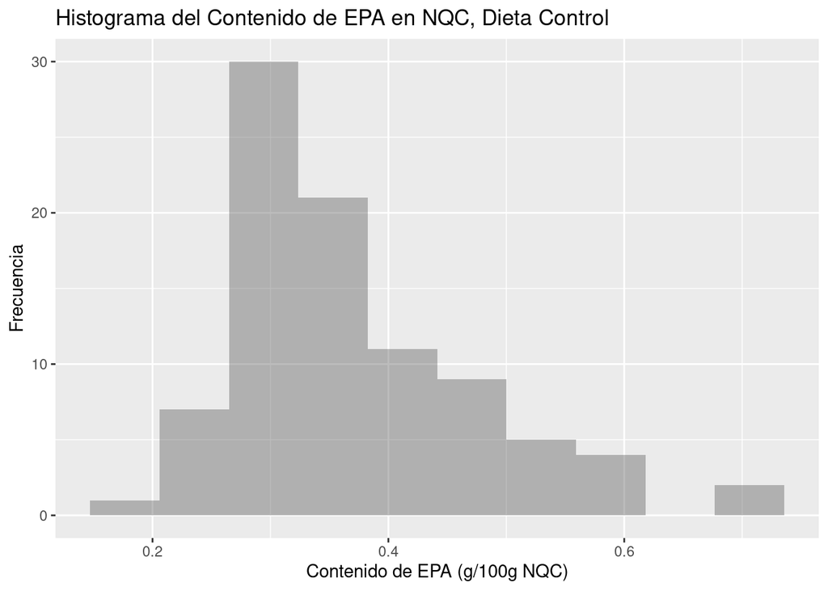

```r
#Descripción de la variación de la variable Contenido de EPA en el músculo de Salmón, en los tiempos 1,2 y 3, cuando fue alimentado con la dieta Control, mediante el uso de histograma
ggplot(TablaEPAC, aes(CantFA))+
  geom_histogram(aes(),position="identity",bins=10,alpha=0.4)+
  ggtitle("Histograma del Contenido de EPA en NQC, Dieta Control")+
    labs(x="Contenido de EPA (g/100g NQC)")+
  labs(y="Frecuencia")
```

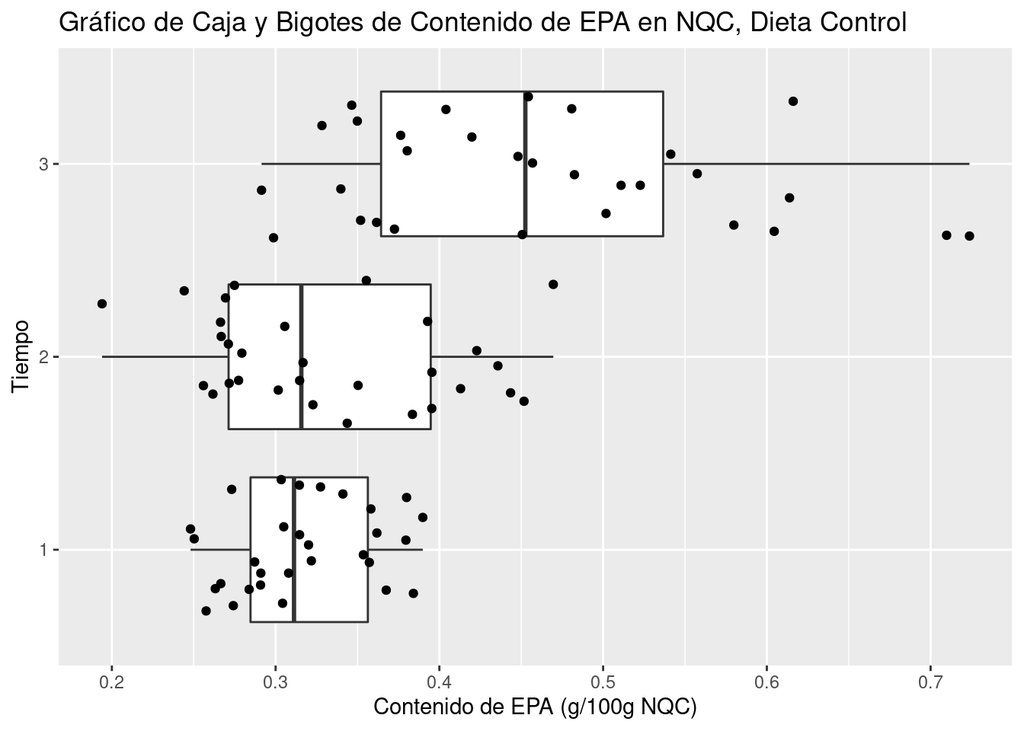

```r
#Análisis de relación entre variables cuantitativas y factores usando gráficas de caja y bigotes
ggplot(TablaEPAC, aes(x=CantFA,y=Tiempo))+
  geom_boxplot()+
  ggtitle("Gráfico de Caja y Bigotes de Contenido de EPA en NQC, Dieta Control")+
  labs(x="Contenido de EPA (g/100g NQC)")+
  geom_jitter()
```

```r
TablaEPAE<-Omega%>%filter(TipoFA=="EPA")%>%filter(Dieta=="Experimental")

TablaEPAE %>% group_by(Tiempo) %>%
  summarize(n=n(), Q1= quantile(CantFA, c(0.25)), Media = mean(CantFA), Mediana = median(CantFA), Q3= quantile(CantFA, c(0.75)), DS = sd(CantFA),  Mín = min(CantFA), Máx = max(CantFA))
```

```
## # A tibble: 3 × 9
##   Tiempo     n    Q1 Media Mediana    Q3     DS   Mín   Máx
##   <fct>  <int> <dbl> <dbl>   <dbl> <dbl>  <dbl> <dbl> <dbl>
## 1 1         30 0.239 0.280   0.281 0.314 0.0445 0.206 0.355
## 2 2         30 0.241 0.264   0.259 0.288 0.0382 0.200 0.353
## 3 3         30 0.304 0.369   0.375 0.424 0.0752 0.230 0.496
```

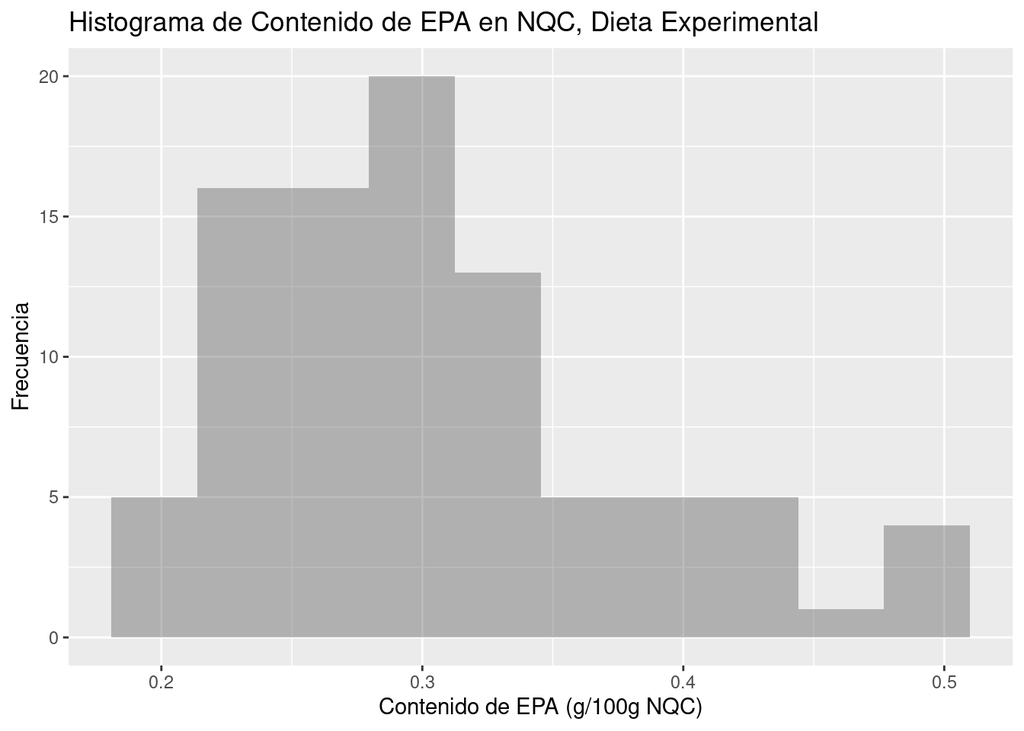

```r
##Descripción de la variación de la variable Contenido de EPA en el músculo de Salmón, en los tiempos 1, 2 y 3, cuando fue alimentado con la dieta Experimental, mediante el uso de histograma

ggplot(TablaEPAE, aes(CantFA))+
  geom_histogram(position="identity",bins=10,alpha=0.4)+
ggtitle("Histograma de Contenido de EPA en NQC, Dieta Experimental")+
labs(x="Contenido de EPA (g/100g NQC)")+
labs(y="Frecuencia")
```

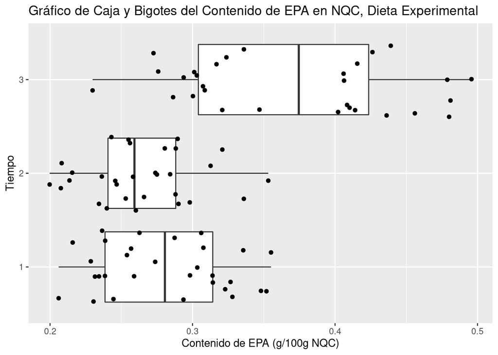

```r
#Análisis de relación entre variables cuantitativas y factores usando gráficas de caja y bigotes

ggplot(TablaEPAE, aes(x=CantFA,y=Tiempo))+
  geom_boxplot()+
  ggtitle("Gráfico de Caja y Bigotes del Contenido de EPA en NQC, Dieta Experimental")+
  labs(x="Contenido de EPA (g/100g NQC)")+
  geom_jitter()
```

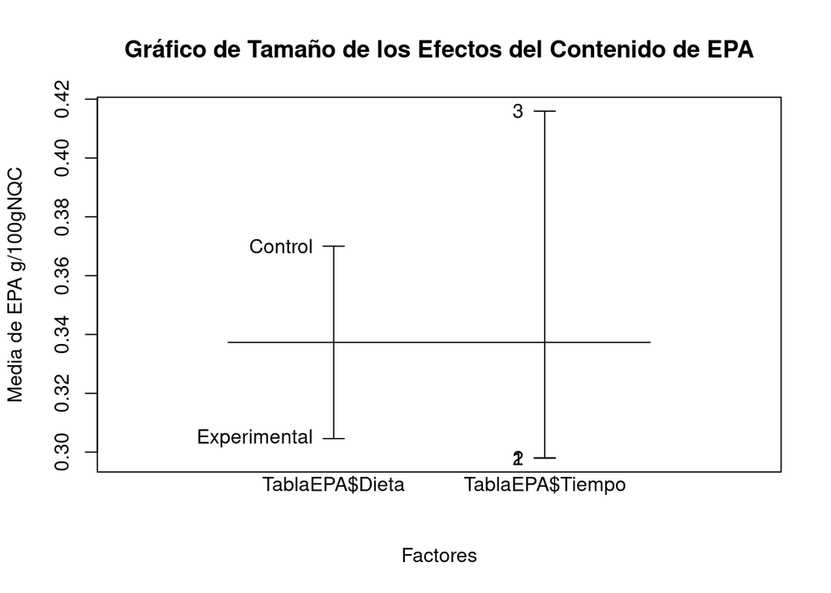

```r
TablaEPA<-Omega%>%filter(TipoFA=="EPA")
#Análisis de relación entre variables cuantitativas y factores usando gráfico de tamaño de los efectos para el contenido de EPA en el músculo de Salmón.
plot.design(TablaEPA$CantFA~TablaEPA$Dieta+TablaEPA$Tiempo, main="Gráfico de Tamaño de los Efectos del Contenido de EPA", ylab="Media de EPA g/100gNQC", xlab = "Factores" )
```

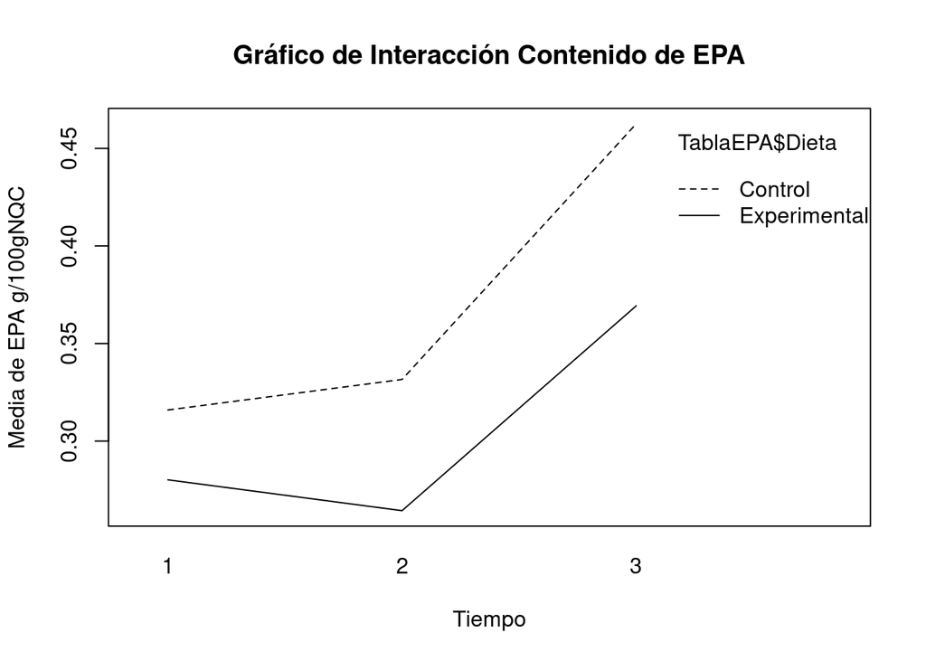

```r
#Análisis de relación entre variables cuantitativas y factores usando gráfico de interacción para el contenido de EPA en el músculo de Salmón.
interaction.plot(TablaEPA$Tiempo,TablaEPA$Dieta,TablaEPA$CantFA, main="Gráfico de Interacción Contenido de EPA", ylab="Media de EPA g/100gNQC", xlab = "Tiempo" )
```

```r
TablaDHAC<-Omega%>%filter(TipoFA=="DHA")%>%filter(Dieta=="Control")
#Descripción de la variación de la variable Contenido de DHA en el músculo de Salmón, en los tiempos 1,2 y 3, cuando fue alimentado con la dieta Control, mediante el uso de histograma

TablaDHAC %>% group_by(Tiempo) %>%
  summarize(n=n(), Q1= quantile(CantFA, c(0.25)), Media = mean(CantFA), Mediana = median(CantFA), Q3= quantile(CantFA, c(0.75)), DS = sd(CantFA),  Mín = min(CantFA), Máx = max(CantFA))
```

```
## # A tibble: 3 × 9
##   Tiempo     n    Q1 Media Mediana    Q3     DS   Mín   Máx
##   <fct>  <int> <dbl> <dbl>   <dbl> <dbl>  <dbl> <dbl> <dbl>
## 1 1         30 0.356 0.394   0.394 0.428 0.0578 0.284 0.514
## 2 2         30 0.365 0.394   0.389 0.417 0.0576 0.278 0.556
## 3 3         30 0.443 0.508   0.499 0.566 0.0902 0.330 0.676
```

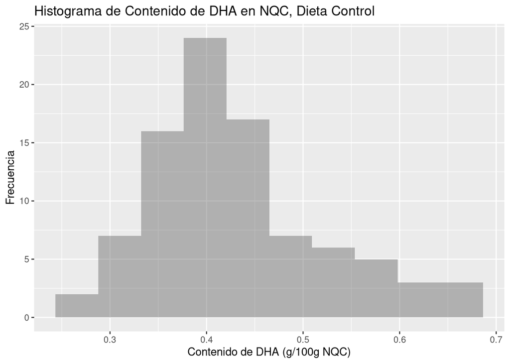

```r
ggplot(TablaDHAC, aes(CantFA))+
  geom_histogram(aes(),position="identity",bins=10,alpha=0.4)+
ggtitle("Histograma de Contenido de DHA en NQC, Dieta Control")+
labs(x="Contenido de DHA (g/100g NQC)")+
labs(y="Frecuencia")
```

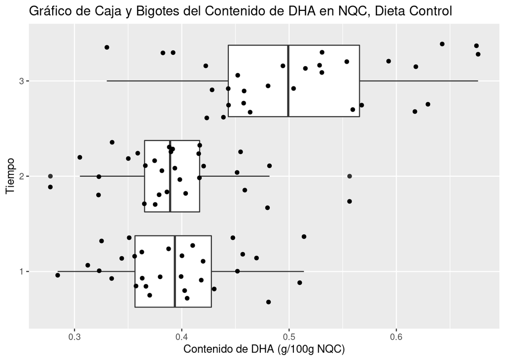

```r
#Análisis de relación entre variables cuantitativas y factores usando gráficas de caja y bigotes
ggplot(TablaDHAC, aes(x=CantFA,y=Tiempo))+
  geom_boxplot()+
  ggtitle("Gráfico de Caja y Bigotes del Contenido de DHA en NQC, Dieta Control")+
  labs(x="Contenido de DHA (g/100g NQC)")+
  geom_jitter()
```

```r
TablaDHAE<-Omega%>%filter(TipoFA=="DHA")%>%filter(Dieta=="Experimental")

TablaDHAE %>% group_by(Tiempo) %>%
  summarize(n=n(), Q1= quantile(CantFA, c(0.25)), Media = mean(CantFA), Mediana = median(CantFA), Q3= quantile(CantFA, c(0.75)), DS = sd(CantFA),  Mín = min(CantFA), Máx = max(CantFA))
```

```
## # A tibble: 3 × 9
##   Tiempo     n    Q1 Media Mediana    Q3     DS   Mín   Máx
##   <fct>  <int> <dbl> <dbl>   <dbl> <dbl>  <dbl> <dbl> <dbl>
## 1 1         30 0.383 0.434   0.417 0.487 0.0618 0.321 0.544
## 2 2         30 0.459 0.504   0.506 0.553 0.0638 0.364 0.608
## 3 3         30 0.605 0.668   0.646 0.731 0.0867 0.555 0.860
```

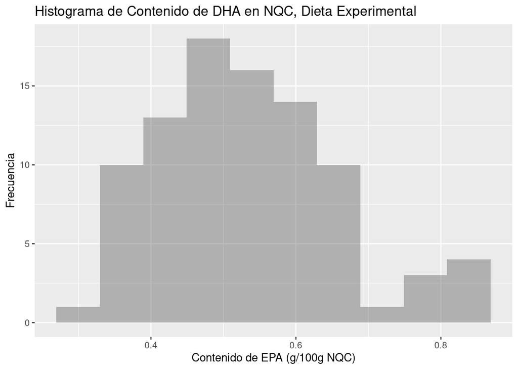

```r
#Descripción de la variación de la variable Contenido de DHA en el músculo de Salmón, en los tiempos 1,2 y 3, cuando fue alimentado con la dieta Experimental, mediante el uso de histogramas
ggplot(TablaDHAE, aes(CantFA))+
  geom_histogram(aes(),position="identity",bins=10,alpha=0.4)+
ggtitle("Histograma de Contenido de DHA en NQC, Dieta Experimental")+
labs(x="Contenido de EPA (g/100g NQC)")+
labs(y="Frecuencia")
```

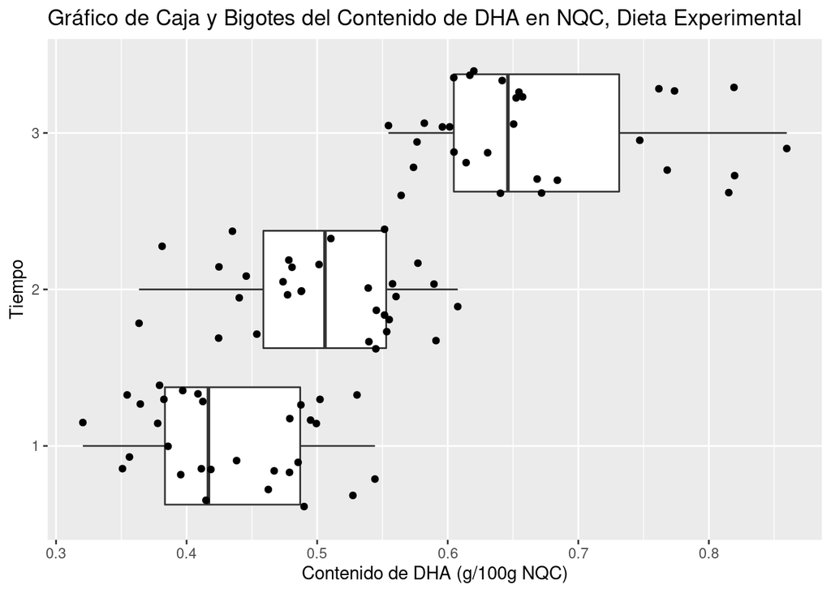

```r
#Análisis de relación entre variables cuantitativas y factores usando gráficas de caja y bigotes
ggplot(TablaDHAE, aes(x=CantFA,y=Tiempo))+
  geom_boxplot()+
  ggtitle("Gráfico de Caja y Bigotes del Contenido de DHA en NQC, Dieta Experimental")+
  labs(x="Contenido de DHA (g/100g NQC)")+
  geom_jitter()
```

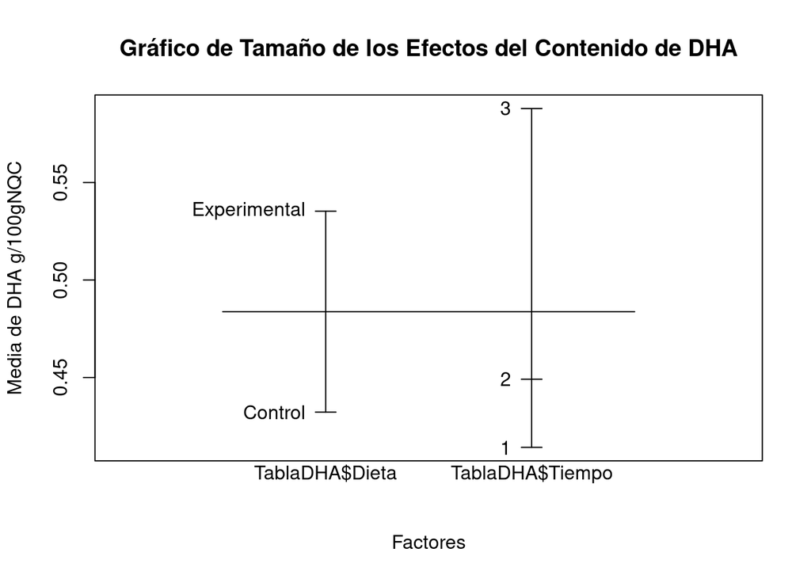

```r
##Análisis de relación entre variables cuantitativas y factores usando gráfico de tamaño de los efectos para el contenido de DHA en el músculo de Salmón.
TablaDHA<-Omega%>%filter(TipoFA=="DHA")
plot.design(TablaDHA$CantFA~TablaDHA$Dieta+TablaDHA$Tiempo, main="Gráfico de Tamaño de los Efectos del Contenido de DHA", ylab="Media de DHA g/100gNQC", xlab = "Factores" )
```

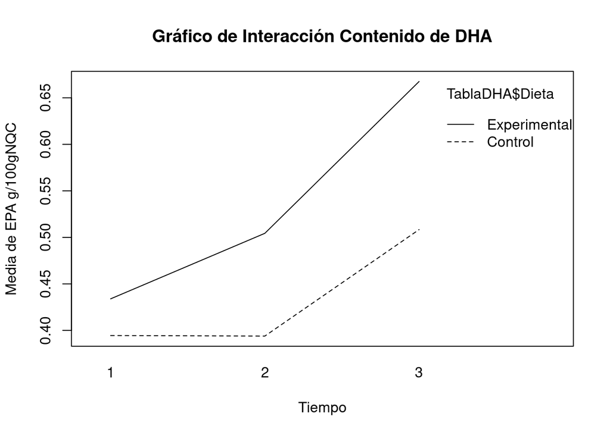

```r
#Análisis de relación entre variables cuantitativas y factores usando gráfico de interacción para el contenido de EPA en el músculo de Salmón.
interaction.plot(TablaDHA$Tiempo,TablaDHA$Dieta,TablaDHA$CantFA, main="Gráfico de Interacción Contenido de DHA", ylab="Media de EPA g/100gNQC", xlab = "Tiempo" )
```

*Gráficos de Cajas y Bigotes para Identificación de Outlayers*

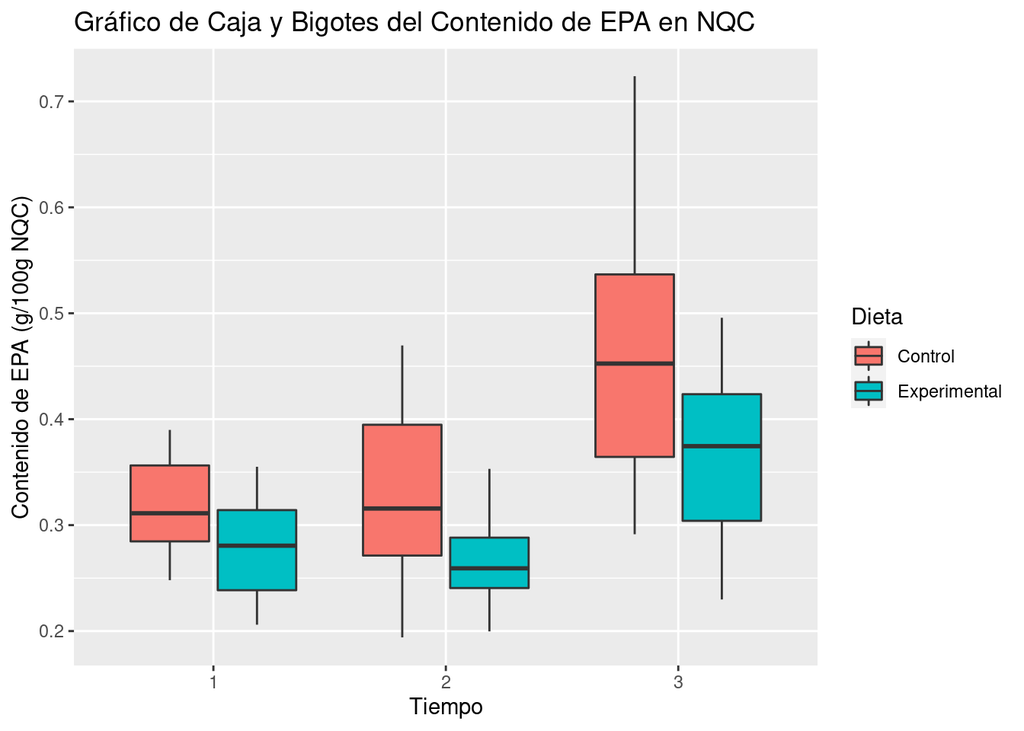

```r
#Análisis de relación entre variables cuantitativas y factores usando gráfico de cajas y bigotes para el contenido de EPA en el músculo de Salmón.
ggplot(TablaEPA, aes(x=Tiempo, y=CantFA, fill=Dieta))+
  geom_boxplot()+
  ggtitle("Gráfico de Caja y Bigotes del Contenido de EPA en NQC")+
  labs(y="Contenido de EPA (g/100g NQC)")+
  labs(x="Tiempo")
```

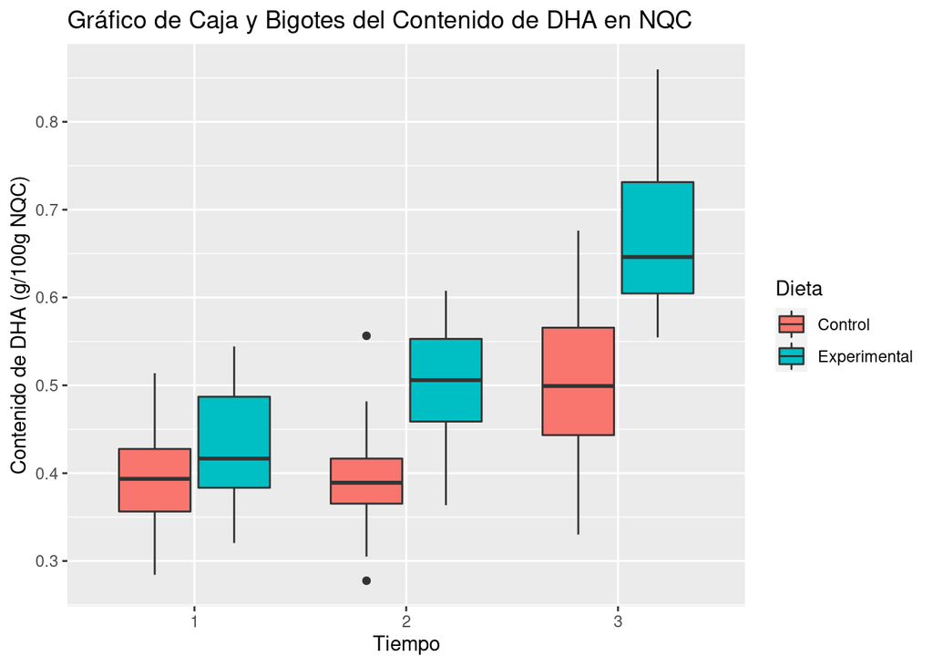

```r
#Análisis de relación entre variables cuantitativas y factores usando gráfico de cajas y bigotes para el contenido de DHA en el músculo de Salmón.
ggplot(TablaDHA, aes(x=Tiempo, y=CantFA, fill=Dieta))+
  geom_boxplot()+
  ggtitle("Gráfico de Caja y Bigotes del Contenido de DHA en NQC")+
  labs(y="Contenido de DHA (g/100g NQC)")+
  labs(x="Tiempo")
```

En la gráfica anterior se identifican outliers en la dieta control durante el muestreo del tiempo 2.

```r
#Análisis de relación entre variables cuantitativas y factores usando gráfico de cajas y bigotes para el contenido de saturados, moninsaturados y polinsaturados en el músculo de Salmón.
TablatipoFA<-Omega%>%filter(TipoFA!="DHA",TipoFA!="EPA",TipoFA!="EPA+ DHA",TipoFA!="Omega 3",TipoFA!="Omega 6", Tiempo=="3")

TablatipoFA %>% group_by(TipoFA,Dieta) %>%
   summarize(n=n(), Q1= quantile(CantFA, c(0.25)), Media = mean(CantFA), Mediana = median(CantFA), Q3= quantile(CantFA, c(0.75)), DS = sd(CantFA),  Mín = min(CantFA), Máx = max(CantFA))
```

```
## # A tibble: 6 × 10
## # Groups:   TipoFA [3]
##   TipoFA          Dieta            n    Q1 Media Mediana    Q3    DS   Mín   Máx
##   <fct>           <fct>        <int> <dbl> <dbl>   <dbl> <dbl> <dbl> <dbl> <dbl>
## 1 Monoinsaturados Control         30  7.10  8.02    7.72  8.69 1.11   6.65 10.7
## 2 Monoinsaturados Experimental    30  7.54  7.93    7.85  8.49 0.704  6.43  9.12
## 3 Polinsaturados  Control         30  4.27  4.73    4.53  5.13 0.705  3.75  6.30
## 4 Polinsaturados  Experimental    30  4.61  4.98    4.94  5.34 0.510  4.07  5.84
## 5 Saturados       Control         30  2.25  2.52    2.40  2.73 0.403  1.89  3.42
## 6 Saturados       Experimental    30  2.21  2.39    2.40  2.56 0.252  2.03  2.87
```

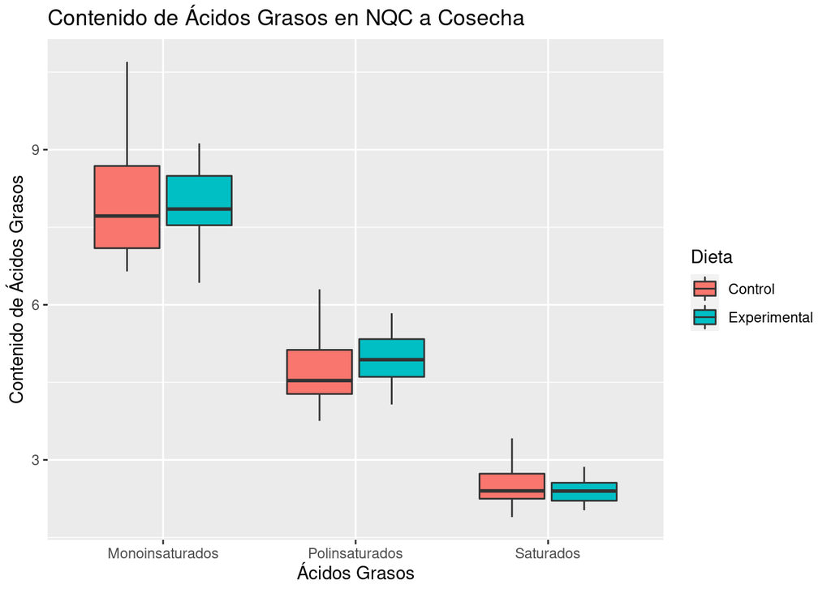

```r
ggplot(TablatipoFA, aes(x=TipoFA, y=CantFA, fill=Dieta))+
  geom_boxplot()+
ggtitle("Contenido de Ácidos Grasos en NQC a Cosecha")+
  labs(y="Contenido de Ác.Grasos (g/100g NQC)")+
labs(y="Contenido de Ácidos Grasos")+
labs(x="Ácidos Grasos")
```

```r
#Análisis de relación entre variables cuantitativas y factores usando gráfico de cajas y bigotes para el contenido de Omega 3 y Omega 6 en el músculo de Salmón.
TablatipoFA<-Omega%>%filter(TipoFA!="DHA",TipoFA!="EPA",TipoFA!="EPA+ DHA",TipoFA!="Monoinsaturados",TipoFA!="Polinsaturados", TipoFA!="Saturados", Tiempo=="3" )

TablatipoFA %>% group_by(TipoFA,Dieta) %>%
   summarize(n=n(), Q1= quantile(CantFA, c(0.25)), Media = mean(CantFA), Mediana = median(CantFA), Q3= quantile(CantFA, c(0.75)), DS = sd(CantFA),  Mín = min(CantFA), Máx = max(CantFA))
```

```
## # A tibble: 4 × 10
## # Groups:   TipoFA [2]
##   TipoFA  Dieta            n    Q1 Media Mediana    Q3    DS   Mín   Máx
##   <fct>   <fct>        <int> <dbl> <dbl>   <dbl> <dbl> <dbl> <dbl> <dbl>
## 1 Omega 3 Control         30  1.85  2.15    2.09  2.33 0.383  1.58  2.95
## 2 Omega 3 Experimental    30  2.23  2.49    2.46  2.70 0.304  1.99  3.05
## 3 Omega 6 Control         30  2.30  2.58    2.51  2.72 0.344  2.15  3.39
## 4 Omega 6 Experimental    30  2.34  2.48    2.52  2.64 0.233  2.03  2.81
```

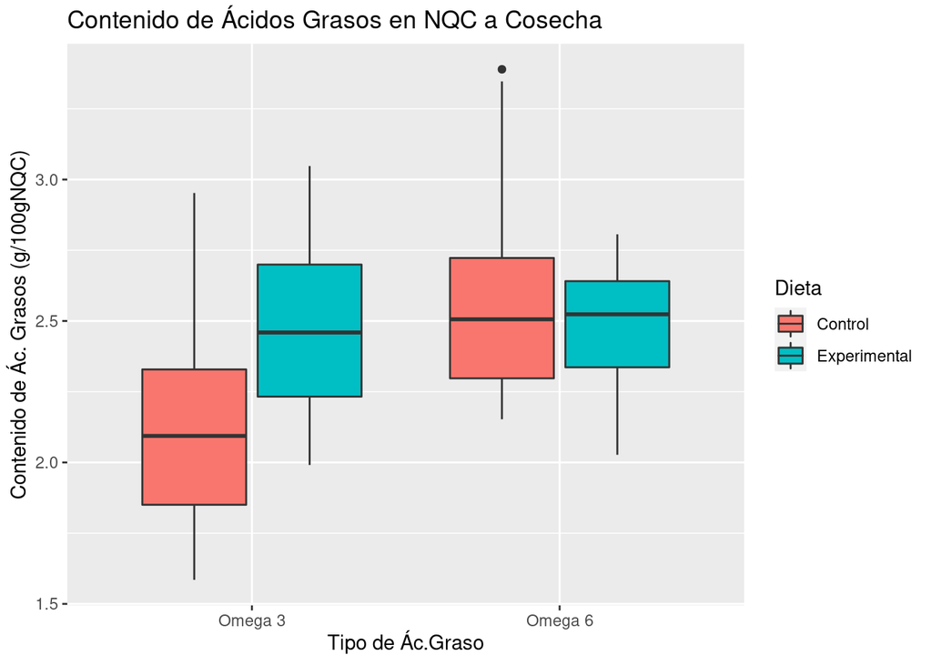

```r
ggplot(TablatipoFA, aes(x=TipoFA, y=CantFA, fill=Dieta))+
  geom_boxplot()+
  ggtitle("Contenido de Ácidos Grasos en NQC a Cosecha")+
  labs(y="Contenido de Ác. Grasos (g/100gNQC)")+
  labs(x="Tipo de Ác.Graso")
```

En el gráfico anterior se identifica un outlier en el contenido de ácidos grasos Omega 6 de la dieta Control

```r
TablatipoFA<-Omega%>%filter(TipoFA!="Omega 3",TipoFA!="Omega 6",TipoFA!="Monoinsaturados",TipoFA!="Polinsaturados", TipoFA!="Saturados", Tiempo=="3")

TablatipoFA %>% group_by(TipoFA,Dieta) %>%
   summarize(n=n(), Q1= quantile(CantFA, c(0.25)), Media = mean(CantFA), Mediana = median(CantFA), Q3= quantile(CantFA, c(0.75)), DS = sd(CantFA),  Mín = min(CantFA), Máx = max(CantFA))
```

```
## # A tibble: 6 × 10
## # Groups:   TipoFA [3]
##   TipoFA   Dieta            n    Q1 Media Mediana    Q3     DS   Mín   Máx
##   <fct>    <fct>        <int> <dbl> <dbl>   <dbl> <dbl>  <dbl> <dbl> <dbl>
## 1 DHA      Control         30 0.443 0.508   0.499 0.566 0.0902 0.330 0.676
## 2 DHA      Experimental    30 0.605 0.668   0.646 0.731 0.0867 0.555 0.860
## 3 EPA      Control         30 0.364 0.463   0.453 0.537 0.117  0.291 0.724
## 4 EPA      Experimental    30 0.304 0.369   0.375 0.424 0.0752 0.230 0.496
## 5 EPA+ DHA Control         30 0.806 0.971   0.982 1.08  0.202  0.677 1.39
## 6 EPA+ DHA Experimental    30 0.900 1.04    1.02  1.14  0.156  0.812 1.34
```

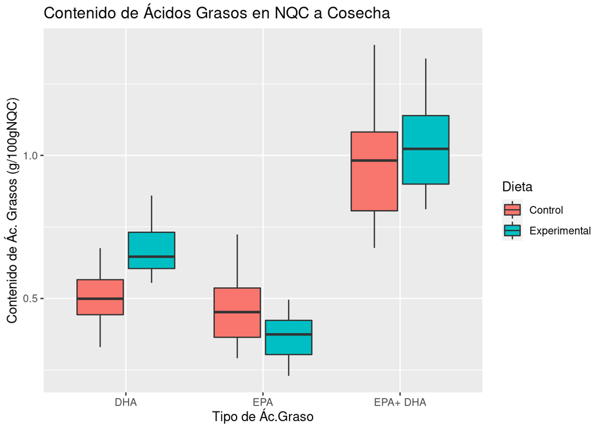

```r
ggplot(TablatipoFA, aes(x=TipoFA, y=CantFA, fill=Dieta))+
  geom_boxplot()+
  ggtitle("Contenido de Ácidos Grasos en NQC a Cosecha")+
    labs(y="Contenido de Ác. Grasos (g/100gNQC)")+
  labs(x="Tipo de Ác.Graso")
```

```r
#Paso para reorganizar los datos, utilizando comando spread de tidyr, de manera tal que se pueda hacer un gráfico de correlación
Omega_Spread<-Omega%>% spread(key = TipoFA, value = CantFA)
```

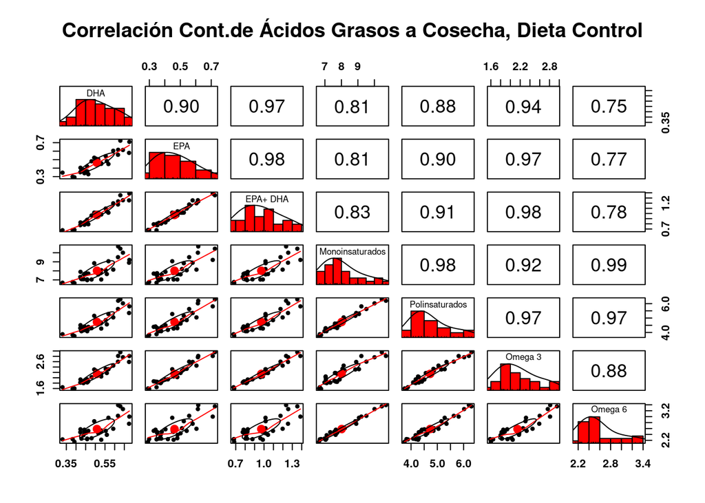

```r
#Análisis de relación entre variables cuantitativas mediante gráfico de correlación múltiple
Omega_Spread<-Omega%>% spread(key = TipoFA, value = CantFA)
OmegaCT3<-Omega_Spread%>% filter(Dieta=="Control", Tiempo=="3")%>%select("DHA","EPA","EPA+ DHA","Monoinsaturados","Polinsaturados","Omega 3","Omega 6")
pairs.panels(OmegaCT3, method = "pearson", hist.col = "red",  density = TRUE, font=2, main="Correlación Cont.de Ácidos Grasos a Cosecha, Dieta Control")
```

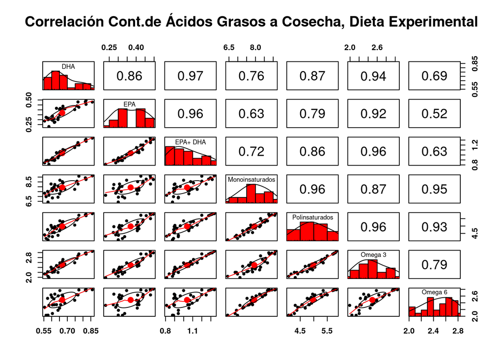

```r
#Análisis de relación entre variables cuantitativas mediante gráfico de correlación múltiple
OmegaET3<-Omega_Spread%>% filter(Dieta=="Experimental", Tiempo=="3")%>%select("DHA","EPA","EPA+ DHA","Monoinsaturados","Polinsaturados","Omega 3","Omega 6")
pairs.panels(OmegaET3, method = "pearson", hist.col = "red",  density = TRUE, font=2, main="Correlación Cont.de Ácidos Grasos a Cosecha, Dieta Experimental")
```

**Análisis Exploratorio de Variables de Desempeño Productivo**

```r
#Exploración inicial para verificar el tipo de variables productivas
summary(Omega2)
```

```
##      Diet             Variable             Valor            Jaula
##  Length:40          Length:40          Min.   :0.5286   Min.   :1
##  Class :character   Class :character   1st Qu.:0.6875   1st Qu.:2
##  Mode  :character   Mode  :character   Median :1.0181   Median :3
##                                        Mean   :1.1805   Mean   :3
##                                        3rd Qu.:1.5604   3rd Qu.:4
##                                        Max.   :2.1390   Max.   :5
```

```r
str(Omega2)
```

```
## tibble [40 × 4] (S3: tbl_df/tbl/data.frame)
##  $ Diet    : chr [1:40] "Experimental" "Experimental" "Experimental" "Experimental" ...
##  $ Variable: chr [1:40] "SFR" "SFR" "SFR" "SFR" ...
##  $ Valor   : num [1:40] 0.816 0.755 0.728 0.736 0.838 ...
##  $ Jaula   : num [1:40] 1 2 3 4 5 1 2 3 4 5 ...
```

```r
#Modificación de las variables que requieren ser consignadas como factor
Omega2$Diet<-as.factor(Omega2$Diet)
Omega2$Variable<-as.factor(Omega2$Variable)
Omega2$Jaula<-as.factor(Omega2$Jaula)
```

```r
#Verificación de la transformación de las variables
str(Omega2)
```

```
## tibble [40 × 4] (S3: tbl_df/tbl/data.frame)
##  $ Diet    : Factor w/ 2 levels "Control","Experimental": 2 2 2 2 2 1 1 1 1 1 ...
##  $ Variable: Factor w/ 4 levels "FCb","GF3","SFR",..: 3 3 3 3 3 3 3 3 3 3 ...
##  $ Valor   : num [1:40] 0.816 0.755 0.728 0.736 0.838 ...
##  $ Jaula   : Factor w/ 5 levels "1","2","3","4",..: 1 2 3 4 5 1 2 3 4 5 ...
```

```r
#Desarrollo de las tablas con el fin de establecer si el ensayo está equilibrado
table(Omega2$Diet)
```

```
##
##      Control Experimental
##           20           20
```

```r
table(Omega2$Variable)
```

```
##
## FCb GF3 SFR SGR
##  10  10  10  10
```

```r
table(Omega2$Diet,Omega2$Variable)
```

```
##
##                FCb GF3 SFR SGR
##   Control        5   5   5   5
##   Experimental   5   5   5   5
```

```r
#No se incluyó table(Omega$Valor) ya que cada observación es una frecuencia, dado que esta es una variable cuantitativa no es posible resumir con este tipo de tabla
```

#Se ha verificado que el ensayo está equilibrado ya que las variables tienen igual cantidad de datos por variable

```r
#Se optó por no hacer histogramas debido a que se cuenta solo con 5 datos por variable, por ello se optó por gráficos de caja y bigotes

Omega2 %>% group_by(Diet, Variable) %>%
   summarize(n=n(), Q1= quantile(Valor, c(0.25)), Media = mean(Valor), Mediana = median(Valor), Q3= quantile(Valor, c(0.75)), DS = sd(Valor),  Mín = min(Valor), Máx = max(Valor))
```

```
## # A tibble: 8 × 10
## # Groups:   Diet [2]
##   Diet         Variable     n    Q1 Media Mediana    Q3     DS   Mín   Máx
##   <fct>        <fct>    <int> <dbl> <dbl>   <dbl> <dbl>  <dbl> <dbl> <dbl>
## 1 Control      FCb          5 1.24  1.33    1.37  1.41  0.107  1.19  1.43
## 2 Control      GF3          5 1.98  2.04    2.08  2.08  0.0768 1.94  2.12
## 3 Control      SFR          5 0.719 0.754   0.725 0.764 0.0581 0.712 0.852
## 4 Control      SGR          5 0.541 0.569   0.575 0.597 0.0334 0.529 0.604
## 5 Experimental FCb          5 1.28  1.32    1.33  1.37  0.0936 1.18  1.43
## 6 Experimental GF3          5 2.03  2.07    2.05  2.14  0.0634 2.00  2.14
## 7 Experimental SFR          5 0.736 0.775   0.755 0.816 0.0493 0.728 0.838
## 8 Experimental SGR          5 0.570 0.588   0.574 0.612 0.0235 0.569 0.615
```

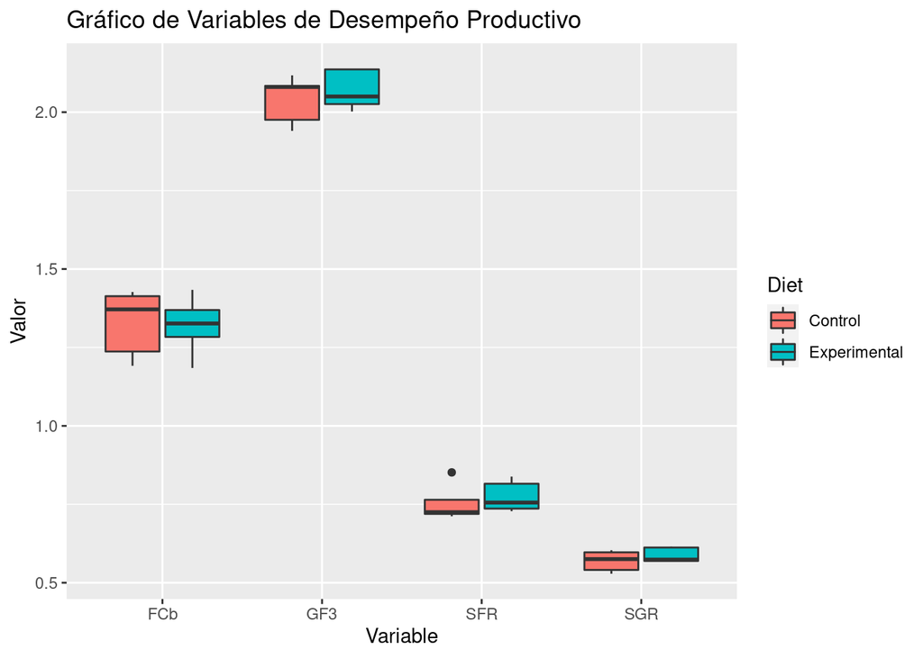

```r
ggplot(Omega2, aes(x=Variable, y=Valor, fill=Diet))+
geom_boxplot()+
labs(y="Valor")+
  ggtitle("Gráfico de Variables de Desempeño Productivo")
```

En el gráfico anterior se identifica un outlier en el SFR de la dieta Control

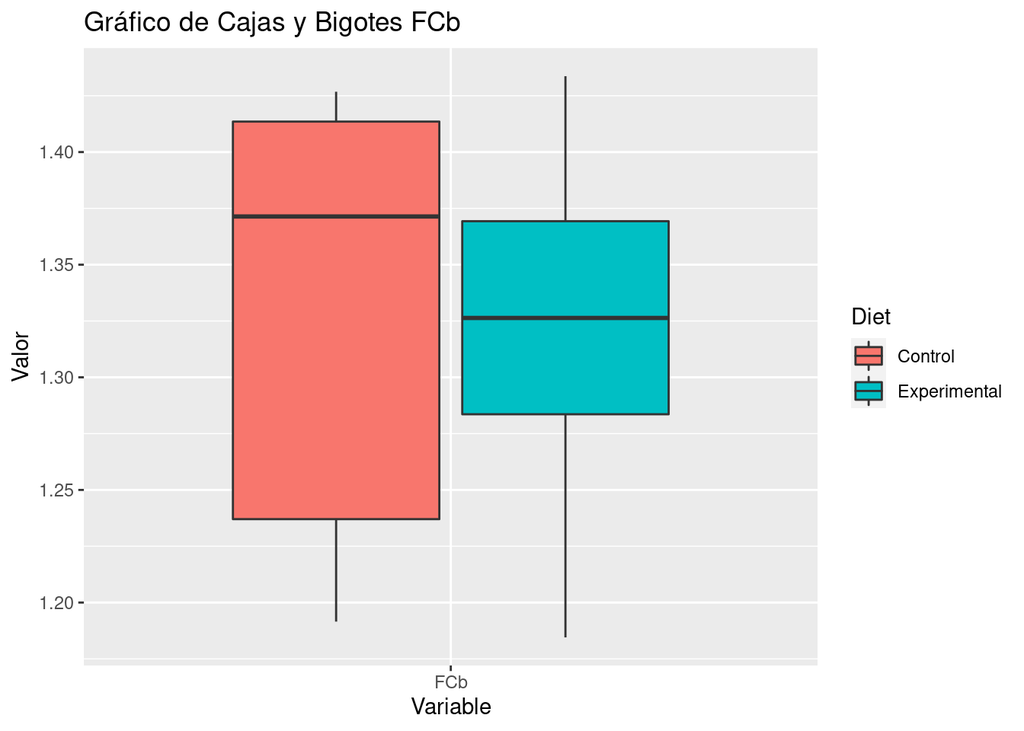

```r
#Análisis de relación entre variables de desempeño productivo y factores usando gráficas de caja y bigotes
Omega2_PerfFCb<-Omega2%>%filter(Variable=="FCb")
ggplot(Omega2_PerfFCb, aes(x=Variable, y=Valor, fill=Diet))+
geom_boxplot()+
labs(y="Valor")+
   ggtitle("Gráfico de Cajas y Bigotes FCb")
```

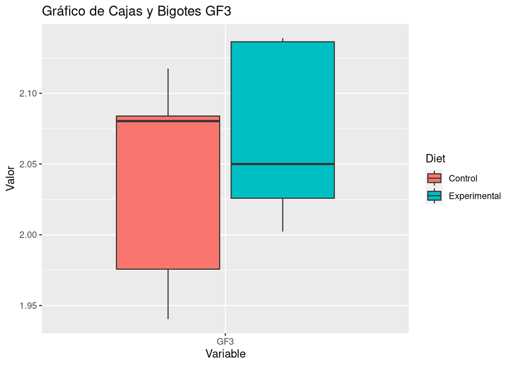

```r
Omega2_PerfGF3<-Omega2%>%filter(Variable=="GF3")
ggplot(Omega2_PerfGF3, aes(x=Variable, y=Valor, fill=Diet))+
geom_boxplot()+
labs(y="Valor")+
ggtitle("Gráfico de Cajas y Bigotes GF3")
```

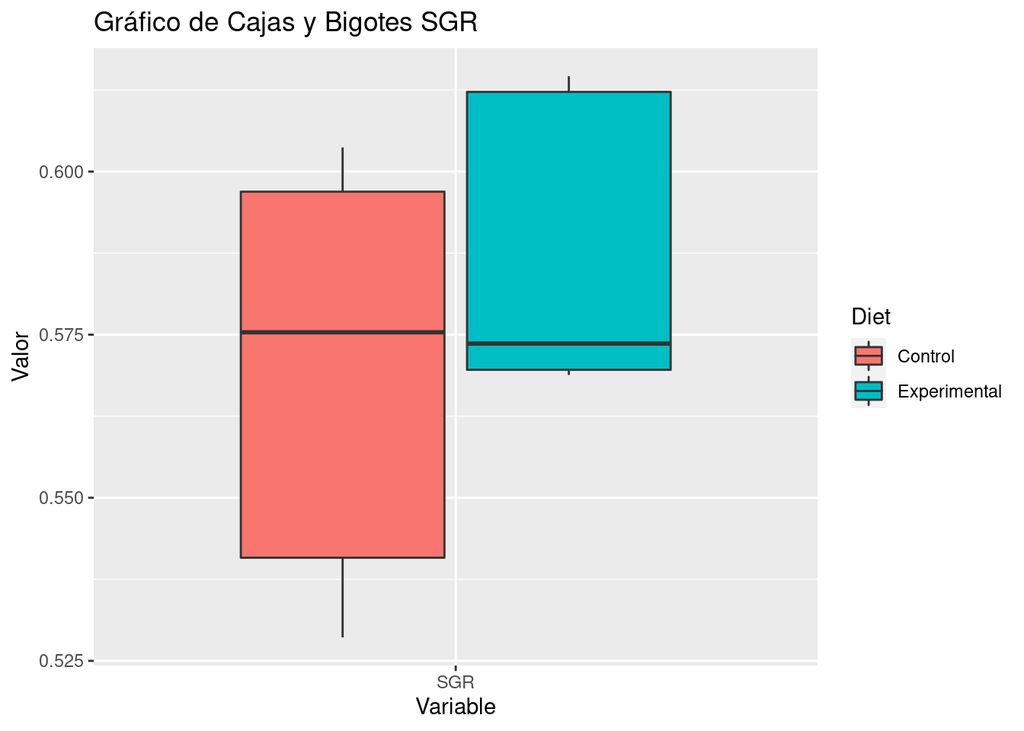

```r
Omega2_PerfSGR<-Omega2%>%filter(Variable=="SGR")
ggplot(Omega2_PerfSGR, aes(x=Variable, y=Valor, fill=Diet))+
geom_boxplot()+
labs(y="Valor")+
ggtitle("Gráfico de Cajas y Bigotes SGR")
```

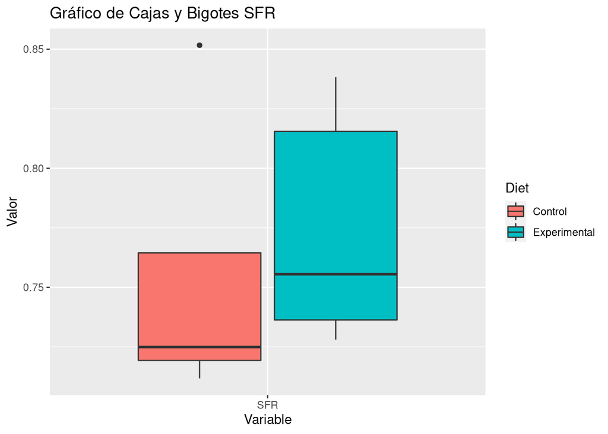

```r
Omega2_PerfSFR<-Omega2%>%filter(Variable=="SFR")
ggplot(Omega2_PerfSFR, aes(x=Variable, y=Valor, fill=Diet))+
geom_boxplot()+
labs(y="Valor")+
ggtitle("Gráfico de Cajas y Bigotes SFR")
```

#En el gráfico anterior se identifica un outlier en el SFR de la dieta Control

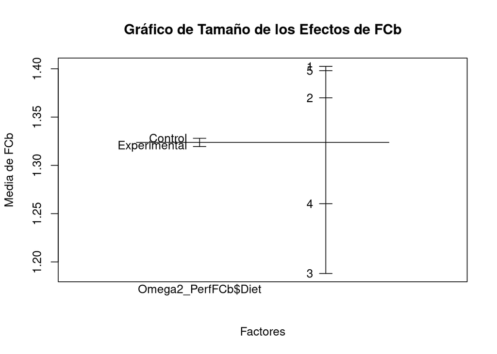

```r
##Análisis de relación entre variables cuantitativas y factores usando gráfico de tamaño de los efectos para las variables de desempeño productivo FCb, GF3, SFR, SGR
plot.design(Omega2_PerfFCb$Valor~Omega2_PerfFCb$Diet+Omega2_PerfFCb$Jaula, main="Gráfico de Tamaño de los Efectos de FCb", ylab="Media de FCb", xlab = "Factores")
```

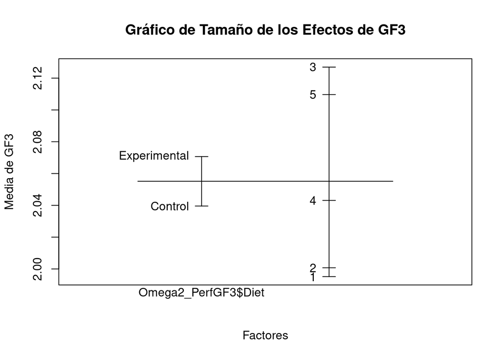

```r
plot.design(Omega2_PerfGF3$Valor~Omega2_PerfGF3$Diet+Omega2_PerfGF3$Jaula, main="Gráfico de Tamaño de los Efectos de GF3", ylab="Media de GF3", xlab = "Factores")
```

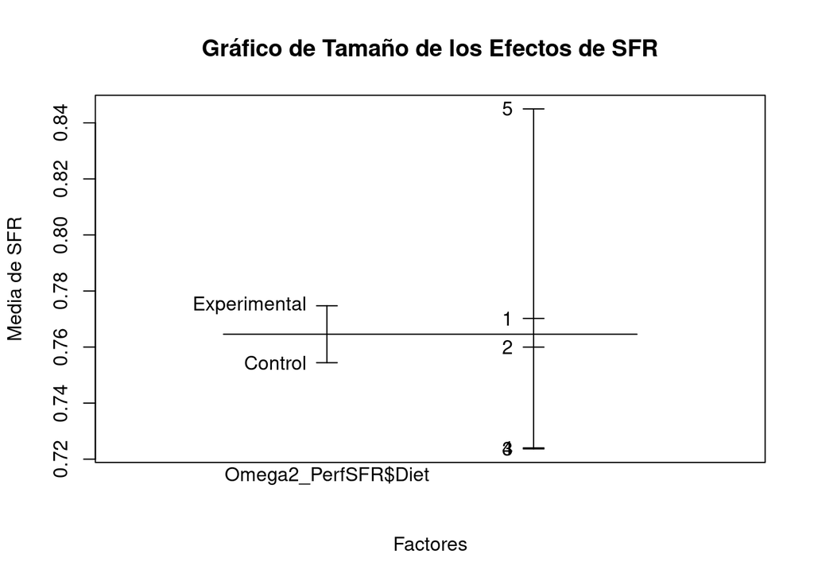

```r
plot.design(Omega2_PerfSFR$Valor~Omega2_PerfSFR$Diet+Omega2_PerfSFR$Jaula, main="Gráfico de Tamaño de los Efectos de SFR", ylab="Media de SFR", xlab = "Factores")
```

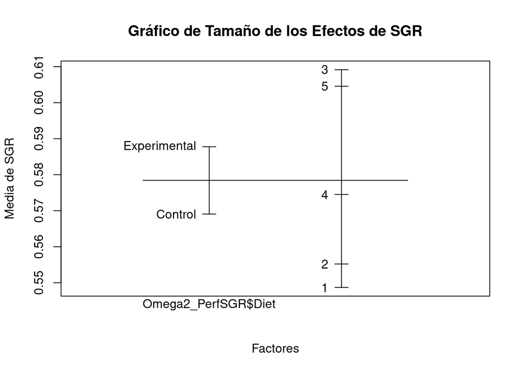

```r
plot.design(Omega2_PerfSGR$Valor~Omega2_PerfSGR$Diet+Omega2_PerfSGR$Jaula, main="Gráfico de Tamaño de los Efectos de SGR", ylab="Media de SGR", xlab = "Factores")
```

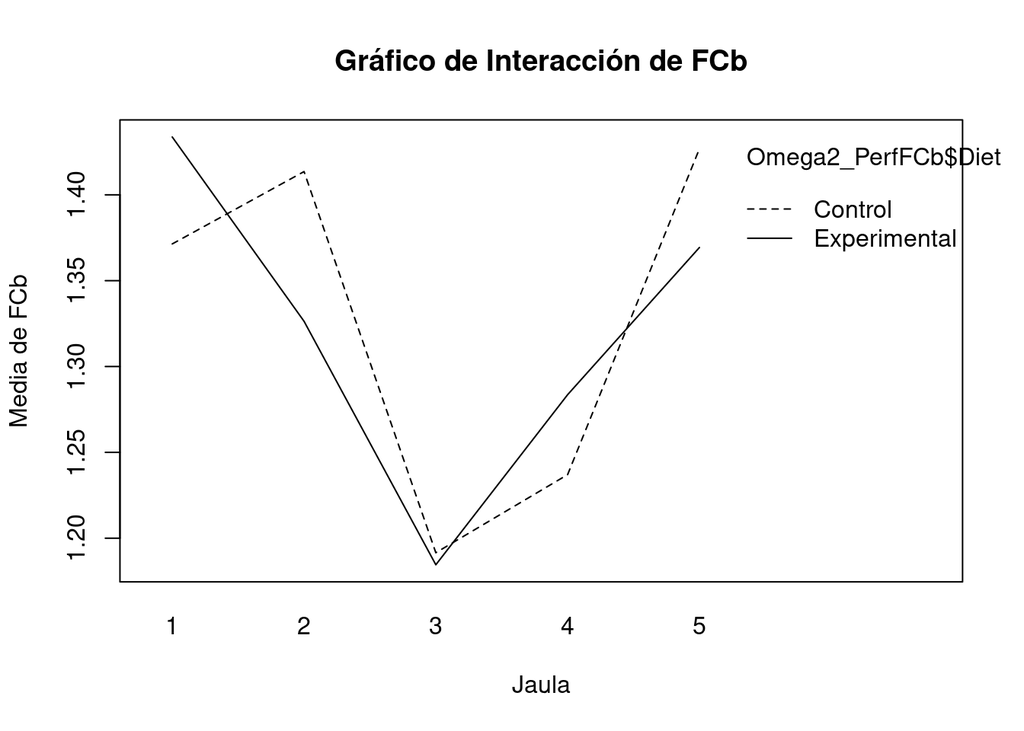

```r
interaction.plot(Omega2_PerfFCb$Jaula,Omega2_PerfFCb$Diet,Omega2_PerfFCb$Valor, main="Gráfico de Interacción de FCb", ylab="Media de FCb", xlab = "Jaula")
```

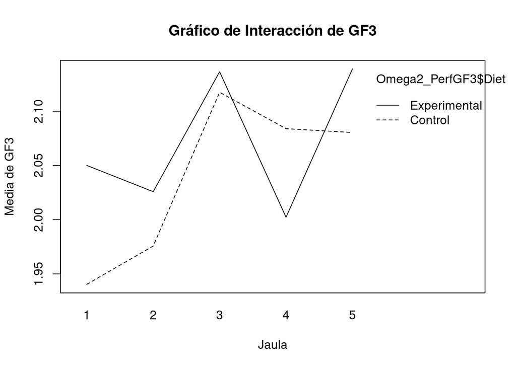

```r
interaction.plot(Omega2_PerfGF3$Jaula,Omega2_PerfGF3$Diet,Omega2_PerfGF3$Valor, main="Gráfico de Interacción de GF3", ylab="Media de GF3", xlab = "Jaula")
```

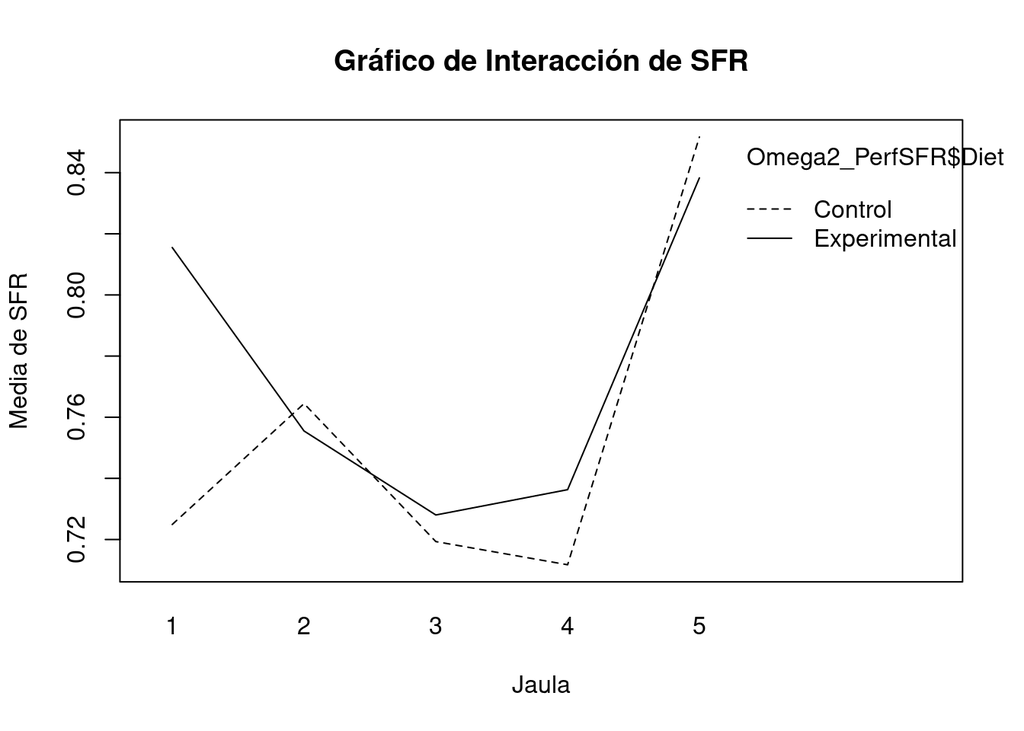

```r
interaction.plot(Omega2_PerfSFR$Jaula,Omega2_PerfSFR$Diet,Omega2_PerfSFR$Valor, main="Gráfico de Interacción de SFR", ylab="Media de SFR", xlab = "Jaula")
```

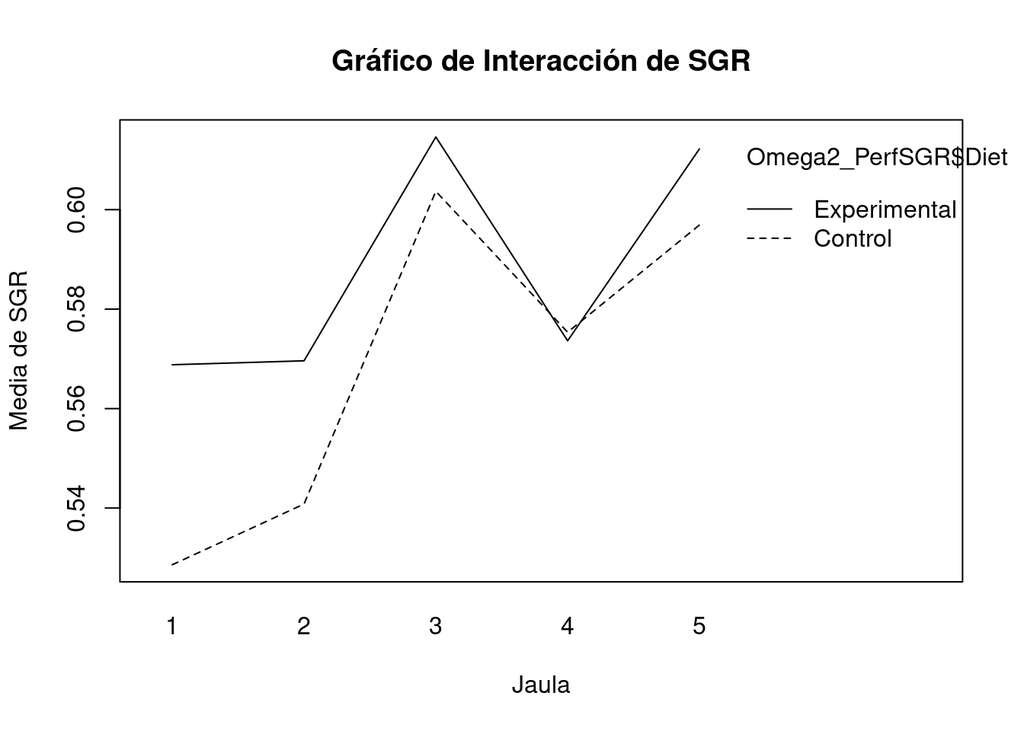

```r
interaction.plot(Omega2_PerfSGR$Jaula,Omega2_PerfSGR$Diet,Omega2_PerfSGR$Valor, main="Gráfico de Interacción de SGR", ylab="Media de SGR", xlab = "Jaula")
```